# Plot Results

Alex Stern

2022-04-28

# Increasing Allele Frequency for Various Traits

This code builds off of a previous pipeline which takes GWAS data and returns the average increasing allele frequency (with confidence intervals) for various phenotypes. Using these output files, this code creates a bar graph that compares the mean increasing allele frequency for a select few of these traits. A p-value threshold of 5e-8 is used throughout this report to create a cutoff for which SNP’s are considered significant.

We first ran the pipeline on a small set of 10 phenotypes to demonstrate desired plots that will come from the broader dataset. The mean increasing allele frequency of the traits are plotted on the y-axis and each bar represents one phenotype.

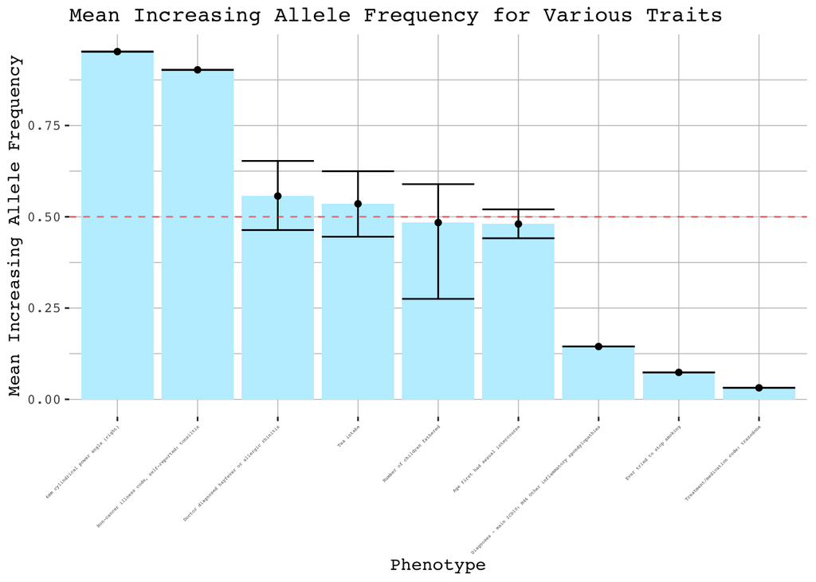

```r
# Read in data
df <- fread("output/results/small_run.txt")

# Remove rows with N/A
df <- df %>%
    drop_na(mean_iaf)

# Create a bar graph with IAF
# data
ggplot(data = df, mapping = aes(x = reorder(phenotype_name,
    -mean_iaf), y = mean_iaf)) +
    geom_col(fill = "lightblue1") +
    theme(axis.text.x = element_text(angle = 45,
        hjust = 1, size = 3)) +
    geom_errorbar(aes(y = mean_iaf,
        ymax = upper_ci, ymin = lower_ci)) +
    geom_point(aes(y = mean_iaf)) +
    geom_hline(yintercept = 0.5,
        alpha = 0.5, linetype = "dashed",
        color = "red") + ggtitle("Mean Increasing Allele Frequency for Various Traits") +
    xlab("Phenotype") + ylab("Mean Increasing Allele Frequency") +
    theme(plot.title = element_text(family = "mono"),
        axis.title.x = element_text(family = "mono"),
        axis.title.y = element_text(family = "mono"),
        axis.text.x = element_text(family = "mono"),
        axis.text.y = element_text(family = "mono"),
        panel.background = element_rect(fill = "white",
            colour = "white", size = 0.5,
            linetype = "solid"),
        panel.grid.major = element_line(size = 0.25,
            linetype = "solid",
            colour = "grey"), panel.grid.minor = element_line(size = 0.25,
            linetype = "solid",
            colour = "grey"))
```

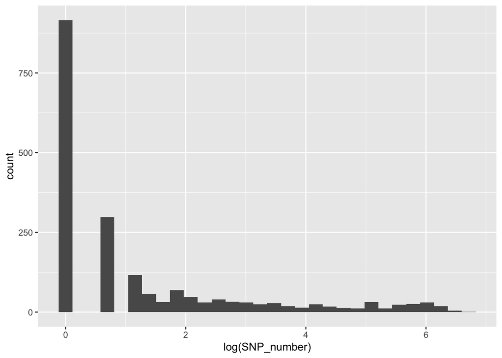

```r
df_all <- fread("output/results/all_5e-8_0.01.txt.gz")
df_all <- drop_na(df_all, SNP_number)
df_all <- distinct(df_all, phenotype_name,
    .keep_all = TRUE)

ggplot(data = df_all, mapping = aes(x = log(SNP_number))) +
    geom_histogram()
```

We then filtered out all traits with less than 10 significant SNPs. The SNP numbers were again plotted in a histogram, not on a logarithmic scale this time.

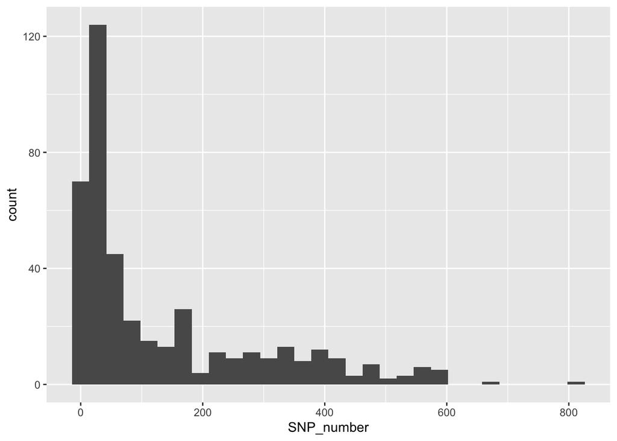

```r
df_10 <- filter(df_all, SNP_number >=
    10)
ggplot(data = df_10, mapping = aes(x = SNP_number)) +
    geom_histogram()
```

To get an idea of the distribution of mean increasing allele frequencies, we plotted each traits mean iaf in a histogram. As the plot shows, most traits have an average increasing allele frequency of 0.5.

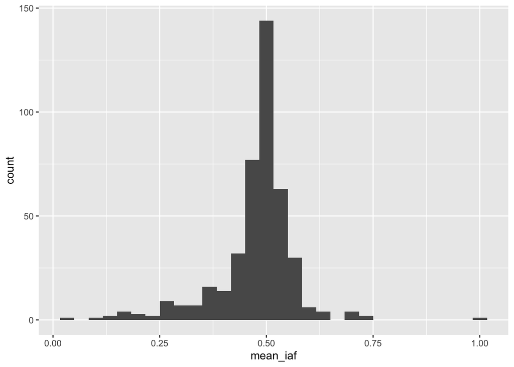

```r
ggplot(data = df_10, mapping = aes(x = mean_iaf)) +
    geom_histogram()
```

We calculated the average of the mean iaf’s for all of the traits with more than 10 SNP’s.

```r
mean_of_mean_iaf <- mean(df_10[,
    mean_iaf])
mean_of_mean_iaf
```

```
## [1] 0.4761936
```

The average is below 0.5, suggesting mutational bias towards increasing alleles.

We then filtered our data into two groups. The first group was of traits with a mean increasing allele frequency statistically significantly higher than 0.5. The second was of traits significantly lower than 0.5. Traits whose confidence intervals included 0.5 we removed entirely.

```r
df_sig_dif <- filter(df_10, lower_ci >
    0.5 | 0.5 > upper_ci)
df_greater_0.5 <- filter(df_sig_dif,
    lower_ci > 0.5)
df_less_0.5 <- filter(df_sig_dif,
    0.5 > upper_ci)
```

```r
num_traits <- nrow(df_10)
traits_greater <- nrow(df_greater_0.5)
percent_greater <- traits_greater/num_traits
traits_less <- nrow(df_less_0.5)
percent_less <- traits_less/num_traits
```

```r
cat("There were ", traits_greater,
    " traits with mean iaf significantly higher than 0.5.
This is ",
    100 * round(percent_greater,
        4), "% of traits with 10 or more significant SNPs.")
```

```
## There were  32  traits with mean iaf significantly higher than 0.5.
## This is  7.46 % of traits with 10 or more significant SNPs.
```

```r
cat("There were ", traits_less,
    " traits with mean iaf significantly lower than 0.5.
This is ",
    100 * round(percent_less, 4),
    "% of traits with 10 or more significant SNPs.")
```

```
## There were  68  traits with mean iaf significantly lower than 0.5.
## This is  15.85 % of traits with 10 or more significant SNPs.
```

```r
plot_data <- function(dat, title) {
    pl <- ggplot(data = dat, mapping = aes(x = reorder(phenotype_name,
        -mean_iaf), y = mean_iaf)) +
        geom_col(fill = "lightblue1") +
        theme(axis.text.x = element_text(angle = 45,
            hjust = 1, size = 3)) +
        geom_errorbar(aes(y = mean_iaf,
            ymax = upper_ci, ymin = lower_ci)) +
        geom_point(aes(y = mean_iaf)) +
        geom_hline(yintercept = 0.5,
            alpha = 0.5, linetype = "dashed",
            color = "red") + ggtitle(title) +
        xlab("Phenotype") + ylab("Mean Increasing Allele Frequency") +
        theme(plot.title = element_text(family = "mono",
            size = 10), axis.title.x = element_text(family = "mono"),
            axis.title.y = element_text(family = "mono"),
            axis.text.x = element_blank(),
            axis.ticks.x = element_blank(),
            axis.text.y = element_text(family = "mono"),
            panel.background = element_rect(fill = "white",
                colour = "white",
                size = 0.5, linetype = "solid"),
            panel.grid.major = element_line(size = 0.25,
                linetype = "solid",
                colour = "grey"),
            panel.grid.minor = element_line(size = 0.25,
                linetype = "solid",
                colour = "grey"))
    return(pl)
}
```

We then plotted the mean increasing allele frequency with error for all of the traits with mean iaf significantly greater than 0.5.

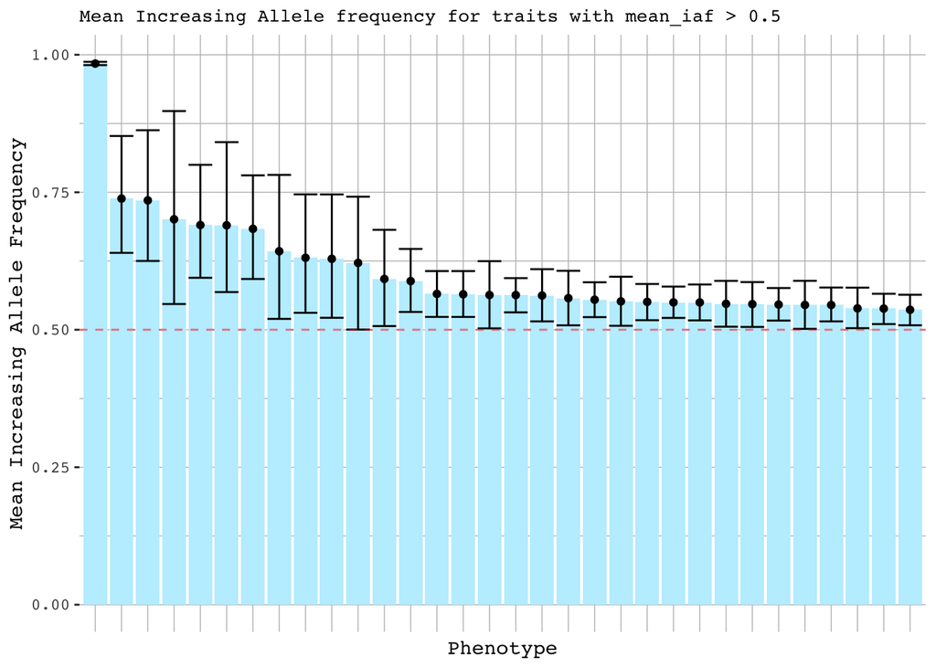

```r
plot_data(df_greater_0.5, "Mean Increasing Allele frequency for traits with mean_iaf > 0.5")
```

The following table contains the phenotype names for all of the traits included in the above graph. They are sorted in the order they appear from left to right.

```r
greater_table <- select(df_greater_0.5,
    c("mean_iaf", "SNP_number",
        "phenotype_name")) %>%
    arrange(desc(mean_iaf))
kable(greater_table)
```

| mean_iaf | SNP_number | phenotype_name |
| --- | --- | --- |
| 0.9840106 | 14 | Both eyes present: Yes |
| 0.7384865 | 10 | Non-oily fish intake |
| 0.7352980 | 10 | Types of physical activity in last 4 weeks: Light DIY (eg: pruning, watering the lawn) |
| 0.7008749 | 12 | Diagnoses - main ICD10: R31 Unspecified haematuria |
| 0.6904252 | 17 | Number of days/week of moderate physical activity 10+ minutes |
| 0.6899265 | 13 | Seen a psychiatrist for nerves, anxiety, tension or depression |
| 0.6835833 | 18 | Potassium in urine |
| 0.6427946 | 15 | Mouth/teeth dental problems: None of the above |
| 0.6308838 | 17 | Salad / raw vegetable intake |
| 0.6289810 | 20 | Diagnoses - main ICD10: N40 Hyperplasia of prostate |
| 0.6215750 | 12 | 3mm cylindrical power (right) |
| 0.5924121 | 21 | Pain type(s) experienced in last month: None of the above |
| 0.5885436 | 61 | Hot drink temperature |
| 0.5652180 | 182 | Cholesterol (mmol/L) |
| 0.5645054 | 180 | Cholesterol (quantile) |
| 0.5631863 | 51 | C-reactive protein (mg/L) |
| 0.5631169 | 290 | HDL cholesterol (quantile) |
| 0.5622314 | 133 | Hair colour (natural, before greying): Dark brown |
| 0.5574454 | 111 | Glucose (quantile) |
| 0.5546298 | 284 | HDL cholesterol (mmol/L) |
| 0.5516103 | 165 | LDL direct (quantile) |
| 0.5506903 | 268 | Apoliprotein A (quantile) |
| 0.5497812 | 329 | Eosinophill count |
| 0.5496864 | 260 | Apoliprotein A (g/L) |
| 0.5471828 | 117 | Spherical power (right) |
| 0.5466209 | 121 | Spherical power (left) |
| 0.5457667 | 303 | Total protein (quantile) |
| 0.5451159 | 170 | LDL direct (mmol/L) |
| 0.5450958 | 293 | Total protein (g/L) |
| 0.5389423 | 172 | Hand grip strength (right) |
| 0.5385134 | 372 | Eosinophill percentage |
| 0.5362948 | 382 | Glycated haemoglobin (quantile) |

Finally, we plotted the mean increasing allele frequency for traits with mean iaf significantly less than 0.5.

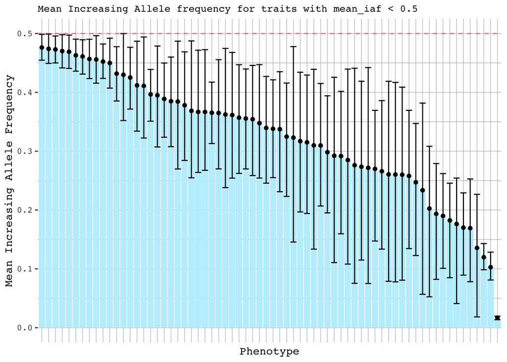

```r
plot_data(df_less_0.5, "Mean Increasing Allele frequency for traits with mean_iaf < 0.5")
```

A table containing the data represented in the bar graph is included below.

```r
less_table <- select(df_less_0.5,
    c("mean_iaf", "SNP_number",
        "phenotype_name")) %>%
    arrange(desc(mean_iaf))
kable(less_table)
```

| mean_iaf | SNP_number | phenotype_name |
| --- | --- | --- |
| 0.4762992 | 436 | Whole body fat mass |
| 0.4740094 | 420 | Red blood cell (erythrocyte) count |
| 0.4729073 | 429 | Arm fat mass (left) |
| 0.4701164 | 336 | High light scatter reticulocyte count |
| 0.4689953 | 346 | High light scatter reticulocyte percentage |
| 0.4629142 | 343 | Haemoglobin concentration |
| 0.4609835 | 321 | Reticulocyte percentage |
| 0.4566873 | 214 | Comparative body size at age 10 |
| 0.4558521 | 171 | 3mm strong meridian (right) |
| 0.4523605 | 325 | Reticulocyte count |
| 0.4499477 | 95 | Smoking status: Never |
| 0.4319116 | 154 | Hair colour (natural, before greying): Blonde |
| 0.4298697 | 12 | Number of operations, self-reported |
| 0.4251808 | 103 | Mean corpuscular haemoglobin concentration |
| 0.4119039 | 37 | Mouth/teeth dental problems: Dentures |
| 0.4110226 | 20 | Smoking status: Current |
| 0.3965677 | 112 | Non-cancer illness code, self-reported: hypothyroidism/myxoedema |
| 0.3950779 | 50 | Direct bilirubin (umol/L) |
| 0.3888699 | 41 | Irritability |
| 0.3849221 | 27 | Medication for pain relief, constipation, heartburn: None of the above |
| 0.3843881 | 11 | Leisure/social activities: Sports club or gym |
| 0.3780944 | 34 | Palmar fascial fibromatosis [Dupuytren] |
| 0.3685937 | 10 | Diseases of the musculoskeletal system and connective tissue |
| 0.3667529 | 16 | Coxarthrosis arthrosis of hip |
| 0.3667529 | 16 | Diagnoses - main ICD10: M16 Coxarthrosis [arthrosis of hip] |
| 0.3653615 | 73 | Treatment/medication code: levothyroxine sodium |
| 0.3649800 | 31 | Fibroblastic disorders |
| 0.3623553 | 18 | Cereal type: Other (e.g. Cornflakes, Frosties) |
| 0.3614701 | 15 | Diagnoses - main ICD10: C50 Malignant neoplasm of breast |
| 0.3570304 | 17 | Cancer code, self-reported: breast cancer |
| 0.3555771 | 31 | Frequency of tiredness / lethargy in last 2 weeks |
| 0.3543538 | 30 | Diagnoses - main ICD10: M72 Fibroblastic disorders |
| 0.3476914 | 14 | Medication related adverse effects |
| 0.3395423 | 24 | Diagnoses - main ICD10: I48 Atrial fibrillation and flutter |
| 0.3380975 | 19 | Disorders of lens |
| 0.3374726 | 15 | Non-cancer illness code, self-reported: migraine |
| 0.3247638 | 15 | Treatment/medication code: thyroxine product |
| 0.3230537 | 12 | Number of fluid intelligence questions attempted within time limit |
| 0.3170245 | 20 | Hair colour (natural, before greying): Red |
| 0.3151430 | 14 | Non-cancer illness code, self-reported: atrial fibrillation |
| 0.3098694 | 10 | Number of self-reported cancers |
| 0.3097428 | 13 | Medication related adverse effects (Asthma/COPD) |
| 0.2983464 | 19 | Cardiac arrhytmias, COPD co-morbidities |
| 0.2922681 | 10 | Cancer diagnosed by doctor |
| 0.2917110 | 13 | Cancer code, self-reported: basal cell carcinoma |
| 0.2850355 | 12 | Venous thromboembolism |
| 0.2761649 | 10 | Blood clot, DVT, bronchitis, emphysema, asthma, rhinitis, eczema, allergy diagnosed by doctor: Blood clot in the leg (DVT) |
| 0.2735533 | 13 | DVT of lower extremities and pulmonary embolism |
| 0.2717945 | 10 | Non-cancer illness code, self-reported: deep venous thrombosis (dvt) |
| 0.2699631 | 14 | Treatment/medication code: insulin product |
| 0.2659029 | 20 | Non-cancer illness code, self-reported: psoriasis |
| 0.2605741 | 11 | Other ILD-related CVD-co-morbidities |
| 0.2603050 | 11 | Diagnoses - main ICD10: I26 Pulmonary embolism |
| 0.2599982 | 10 | DVT of lower extremities |
| 0.2580085 | 12 | Started insulin within one year diagnosis of diabetes |
| 0.2472024 | 13 | Medication for cholesterol, blood pressure or diabetes: Insulin |
| 0.2336803 | 12 | Treatment/medication code: rosuvastatin |
| 0.2025516 | 11 | Endocrine, nutritional and metabolic diseases |
| 0.1935038 | 12 | Medication for cholesterol, blood pressure, diabetes, or take exogenous hormones: Insulin |
| 0.1900540 | 21 | Non-cancer illness code, self-reported: malabsorption/coeliac disease |
| 0.1823798 | 10 | Non-cancer illness code, self-reported: sarcoidosis |
| 0.1763187 | 11 | Diagnoses - main ICD10: K90 Intestinal malabsorption |
| 0.1700973 | 13 | Non-cancer illness code, self-reported: hyperthyroidism/thyrotoxicosis |
| 0.1691988 | 10 | Treatment/medication code: warfarin |
| 0.1356605 | 11 | Non-cancer illness code, self-reported: rheumatoid arthritis |
| 0.1198611 | 10 | Never eat eggs, dairy, wheat, sugar: Wheat products |
| 0.1028306 | 11 | Coeliac disease |
| 0.0169908 | 34 | Distance between home and job workplace |

Based on the data, it seems that traits are approximately slightly biased towards a mean_iaf of below 0.5. This matches theoretical expectations regarding mutational biases towards traits with lower mean_iaf.